# Boletin Técnico Agroclimático Nacional - Distritos de Riego

### Pronóstico de tiempo (7 dias)

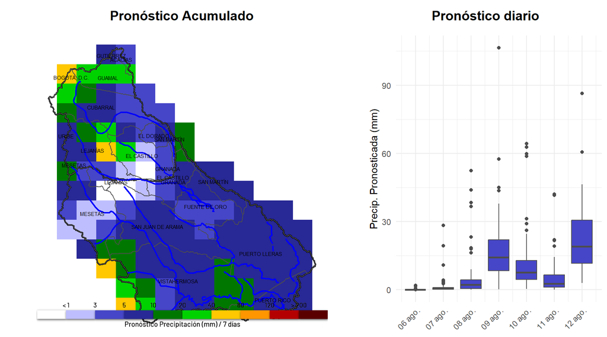

Para la próxima semana en la **Cuenca_Rio-Ariari_Meta**, se anticipan variaciones significativas en las precipitaciones. Los días con mayores volúmenes esperados son el 9 y el 12 de agosto, donde se prevén precipitaciones intensas. El 9 de agosto se estima que habrá volúmenes elevados, con una mediana que indica lluvias de considerable magnitud. Posteriormente, el 10 de agosto, se esperan volúmenes moderados a elevados, pero sin alcanzar la intensidad del día anterior. El 11 de agosto se prevén precipitaciones moderadas, mientras que el 8 de agosto se anticipan lluvias leves.

En términos de probabilidades de tiempo húmedo, los porcentajes indican que, a partir del 8 de agosto, la probabilidad de lluvias aumenta significativamente, alcanzando un 75.3%. Para el 9 y 10 de agosto, las probabilidades son extremadamente altas, superiores al 97%, lo que sugiere que es muy probable que se presenten lluvias en estos días. El 11 de agosto también muestra altas probabilidades de tiempo húmedo, y el 12 de agosto se prevé que sea casi seguro con un 100% de probabilidad de lluvia. Esta tendencia sugiere un patrón de humedad persistente que puede influir positivamente en la agricultura, aunque también se debe estar alerta ante el riesgo de inundaciones en días de intensas precipitaciones.

(IDEAM - WRF COLOMBIA)

### Seguimiento Meteorológico

**Nota:** para esta cuenca no existe información meteorológica.

## Cuenca Río Úpia

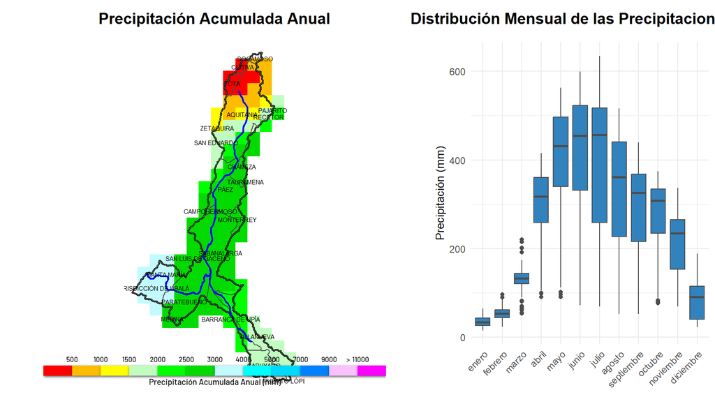

Los riesgos para los productores durante la estación lluviosa incluyen el potencial de inundaciones y erosión del suelo, por lo que es recomendable implementar prácticas de conservación de suelos y drenaje adecuado. En contraste, durante la temporada seca, es crucial planificar el riego y seleccionar cultivos resistentes a la falta de agua para optimizar la producción.

### Predicción Climática (6 meses)

#### Análisis del comportamiento histórico de la precipitación en la cuenca Cuenca Rio Upia Meta

La cuenca del Rio Upia Meta presenta un comportamiento pluviométrico característico a lo largo de los próximos seis meses. Históricamente, se observa que en agosto las precipitaciones alcanzan una mediana de 375.4 mm, lo que indica un régimen de lluvias intenso. Este nivel de precipitación puede generar un riesgo elevado de crecientes y desbordamientos en los afluentes, afectando la disponibilidad de agua en la región.

A medida que avanza el calendario, en septiembre, la mediana de lluvia disminuye a 337.4 mm, manteniendo un nivel intenso que también puede acentuar el riesgo de crecientes. En octubre, las precipitaciones continúan en un rango alto con una mediana de 318.5 mm, lo que refuerza la tendencia a un comportamiento lluvioso significativo.

Sin embargo, a partir de noviembre, se observa un cambio notable en el régimen pluviométrico, donde la mediana desciende a 239.3 mm, lo que se clasifica como normal. Este descenso puede contribuir a una estabilización en los niveles del río, mejorando la disponibilidad de agua para los cultivos. En diciembre, las lluvias caen drásticamente a 91.3 mm, indicando un periodo de sequía, donde la disponibilidad de agua se ve comprometida, afectando especialmente a la agricultura.

Finalmente, en enero, se prevé una mediana de solo 35.5 mm, lo que clasifica la precipitación como muy baja, y podría generar niveles críticos de agua en los afluentes, afectando la gestión hídrica y los cultivos en la región. Este análisis subraya la importancia de un monitoreo continuo del comportamiento de las precipitaciones para la planificación agrícola y la gestión de recursos hídricos en la cuenca.

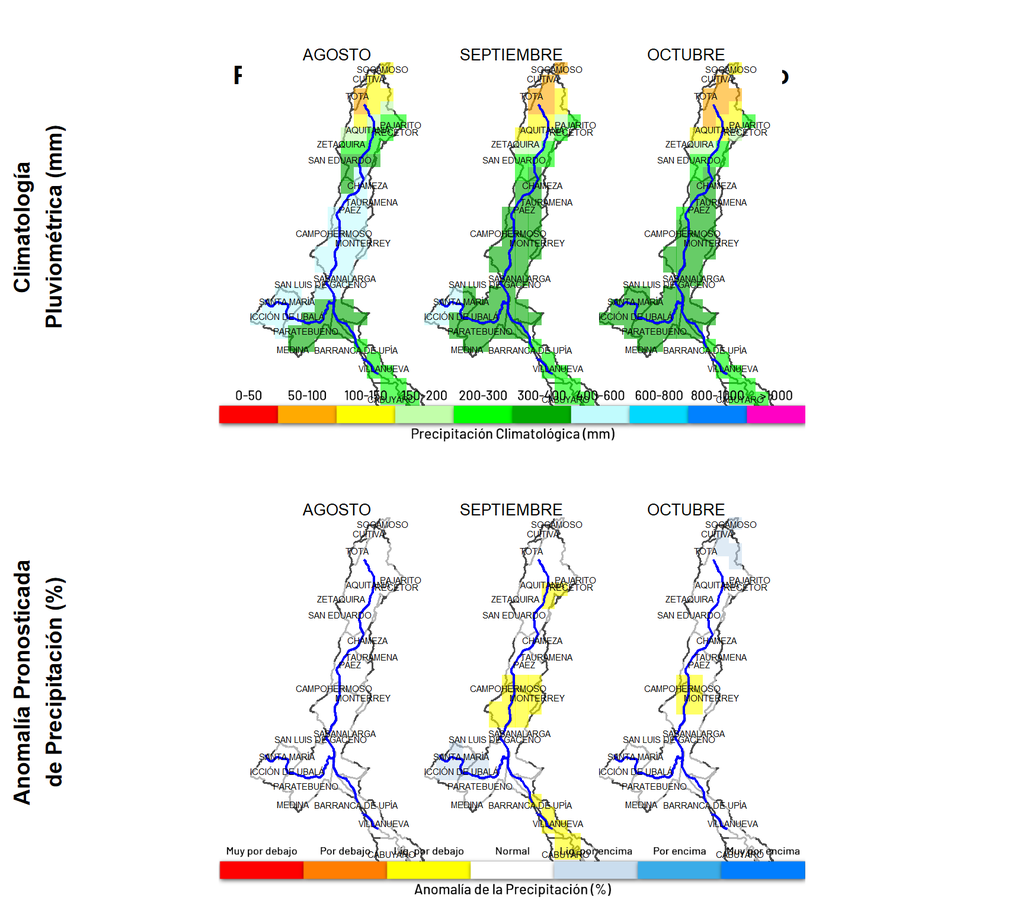

#### Análisis de cambios en la precipitación acumulada para la cuenca Río Upía Meta

La cuenca Río Upía Meta presenta una serie de variaciones en los pronósticos de precipitación acumulada para los próximos meses. En agosto de 2025, se prevé una **reducción moderada** del 1.7%, lo que sugiere una ligera disminución en la disponibilidad de agua en ese período. Sin embargo, en septiembre se anticipa una **reducción importante** del 6.1%, lo que podría tener implicaciones significativas en los cultivos y en la gestión del recurso hídrico.

A partir de octubre, las proyecciones muestran un cambio positivo con un **incremento leve** del 1.4%. Noviembre se prevé con un **incremento moderado** del 15.7%, seguido de otro **incremento moderado** del 7.3% en diciembre. Estos aumentos son alentadores, ya que indican una mejora en las condiciones hídricas hacia el final del año.

Finalmente, enero de 2026 se presenta con un **incremento considerable** del 13.7%, lo que podría beneficiar a la agricultura local, especialmente a los cultivos de arroz, que dependen de condiciones óptimas de humedad. En resumen, aunque se anticipan reducciones en los primeros meses, el final del año y el comienzo de 2026 ofrecen perspectivas más favorables para la cuenca Río Upía Meta.

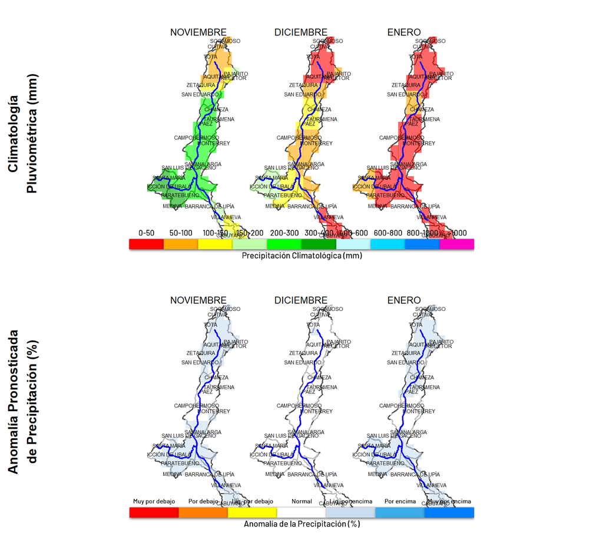

#### Pronóstico de precipitación para la Cuenca Río Upia Meta

Se prevé que durante los próximos meses la Cuenca Río Upia Meta experimente una notable variación en los volúmenes de precipitación. Según los pronósticos, se anticipa que en agosto de 2025, las lluvias alcancen un total de **376.9 mm**, con una probabilidad de acierto del **54%**. Este volumen es considerablemente alto, lo que podría generar un riesgo de **inundaciones** en la región si se supera el umbral de los **300 mm**.

Para septiembre, los modelos indican que la precipitación disminuirá a **315.4 mm**, pero la probabilidad de acierto aumenta al **59%**. Aunque la probabilidad de inundaciones sigue siendo relevante, la situación podría ser menos crítica en comparación con agosto, siempre que las lluvias no superen los niveles pronosticados.

En octubre, se espera que las lluvias continúen con un pronóstico de **311.4 mm** y una probabilidad de acierto del **57%**. A pesar de que la tendencia es a la baja, el riesgo de inundaciones persiste.

En noviembre, se prevé que las precipitaciones bajen a **259.5 mm**, con una probabilidad de acierto del **65%**, lo que sugiere que la situación podría estabilizarse, aunque aún se deben considerar los riesgos asociados.

Finalmente, en diciembre y enero, las lluvias se reducirán drásticamente a **97.4 mm** y **39.3 mm**, respectivamente, con probabilidades de acierto del **61%** y **66%**. Estas cifras indican un riesgo de **estrés hídrico**, especialmente en enero, donde se pronostica un volumen de precipitación muy bajo.

En resumen, la evolución de las precipitaciones en la Cuenca Río Upia Meta presenta riesgos significativos de inundación en los meses iniciales, seguidos de una posible escasez de agua hacia principios de 2026. La fiabilidad de los pronósticos se mantiene moderada, con probabilidades de acierto que oscilan entre el 54% y el 66%.

### Pronóstico de tiempo (7 dias)

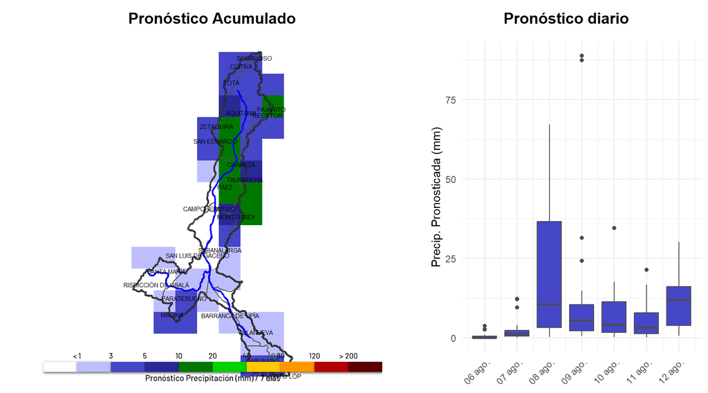

Para la cuenca **Cuenca_Rio-Upia_Meta**, se prevé una semana con variabilidad significativa en las precipitaciones. Los días con mayores volúmenes esperados son el 8 y el 12 de agosto, donde se anticipan precipitaciones intensas, lo que podría resultar en volúmenes elevados. En contraste, el 6 y 7 de agosto se caracterizan por una ausencia de lluvias, lo que se traduce en volúmenes mínimos. Entre el 9 y el 11 de agosto, se pronostican precipitaciones moderadas, que aportarán volúmenes intermedios, contribuyendo a la humedad del suelo, pero no alcanzando los niveles de los días más intensos.

Analizando las probabilidades de tiempo húmedo, se observa que el 6 de agosto presenta un 26.9% de puntos con lluvia, indicando altas probabilidades de tiempo seco. Sin embargo, a partir del 7 de agosto, las probabilidades aumentan significativamente, alcanzando el 80.8% y culminando en un 100% el 9 y 12 de agosto, lo que sugiere una semana mayormente húmeda, especialmente en la segunda mitad. Esto es favorable para los cultivos que requieren humedad, aunque se debe estar atento a las precipitaciones intensas que podrían ocasionar escorrentías o erosión en suelos vulnerables.

(IDEAM - WRF COLOMBIA)

### Seguimiento Meteorológico

**Nota:** para esta cuenca no existe información meteorológica.

# Cuencas Caribe Seco

## Cuenca El Zulia - Norte de Santander

La cuenca del río Zulia, situada en el departamento de Norte de Santander, se extiende aproximadamente sobre 1800 km² y comprende municipios como San Cayetano, Salazar de Las Palmas, El Zulia y parte de Cúcuta. Nace en las estribaciones de la serranía de Los Motilones, a más de 2000 m s.n.m., y desciende hacia el valle del río Pamplonita, confluyendo cerca de la represa del mismo nombre.

Los suelos de la cuenca, en sus tramos altos, son ideales para café de altura y frutales (aguacate, mora), mientras que en la parte media y baja se desarrollan cultivos de maíz, fríjol y pasturas para ganadería de doble propósito.

La represa del río Pamplonita, que regula parte del caudal del Zulia, suministra agua para riego y consumo urbano en el área metropolitana de Cúcuta, así como energía hidroeléctrica en pequeña escala. La pendiente pronunciada en su tramo superior exige prácticas de conservación de suelos—como terrazas y coberturas vegetales—para mitigar la erosión y sedimentos.

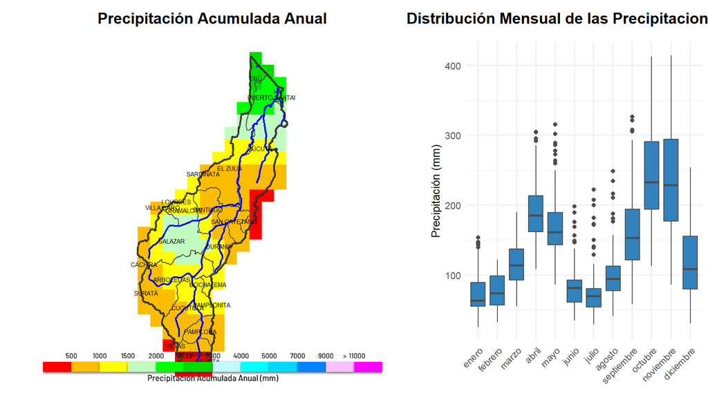

El comportamiento histórico de las precipitaciones en la cuenca El Zulia, Norte de Santander, durante los próximos meses (agosto a enero) revela patrones distintivos. En agosto, las precipitaciones son generalmente bajas (mediana de 94.8 mm), lo que puede limitar el crecimiento de cultivos que requieren mayor humedad. Septiembre marca un aumento significativo, con mediana de 153 mm, ofreciendo condiciones más favorables para el cultivo y la siembra. Octubre y noviembre son los meses más lluviosos del año, con medianas de 232.6 mm y 228.5 mm, respectivamente, lo que puede generar riesgos de inundaciones y erosión, por lo que se recomienda a los productores prepararse para el manejo del agua.

Diciembre presenta una disminución en las precipitaciones (108.9 mm), y enero, aunque también tiene precipitaciones bajas (63.7 mm), marca el inicio del ciclo seco. La cuenca El Zulia exhibe un régimen bimodal, con dos temporadas secas al año. La primera temporada seca ocurre de junio a julio, y la segunda desde enero hasta finales de febrero. Esto implica que los productores deben planificar sus cultivos teniendo en cuenta estas variaciones estacionales, optando por especies que se adapten a las condiciones de humedad en cada etapa del año.

### Predicción Climática (6 meses)

#### Análisis del comportamiento histórico de la precipitación en la cuenca Cuenca El Zulia Norte de Santander

El régimen de lluvias en la cuenca Cuenca El Zulia Norte de Santander presenta un comportamiento variable a lo largo de los meses, con precipitaciones que afectan significativamente la disponibilidad de agua en la región. Durante los próximos seis meses, las cifras de precipitación mediana son las siguientes:

- **Agosto:** 98.1 mm (Bajo)
- **Septiembre:** 155.4 mm (Normal)
- **Octubre:** 235.9 mm (Normal)
- **Noviembre:** 235.4 mm (Normal)
- **Diciembre:** 113.5 mm (Bajo)
- **Enero:** 67.8 mm (Bajo)

Históricamente, se observa que agosto presenta un nivel de precipitación mediana de 98.1 mm, lo que indica un régimen de lluvias bajo y puede resultar en niveles críticos de los afluentes. En contraste, el período de octubre y noviembre se destaca por precipitaciones normales, con valores de 235.9 mm y 235.4 mm, respectivamente. Estos niveles de lluvia son cruciales, ya que pueden generar un aumento significativo en los niveles del río, elevando el riesgo de crecientes y desbordamientos.

Por otro lado, diciembre y enero vuelven a mostrar precipitaciones bajas, con 113.5 mm y 67.8 mm, lo que puede limitar la disponibilidad de agua para los cultivos y el abastecimiento en la región. La mediana de agosto es la única que se encuentra por debajo de los 100 mm, lo que puede afectar la capacidad de los afluentes para mantener un flujo adecuado. En resumen, la cuenca experimenta un ciclo de lluvias que varía de bajo a normal, con implicaciones directas en la gestión del agua y la agricultura local.

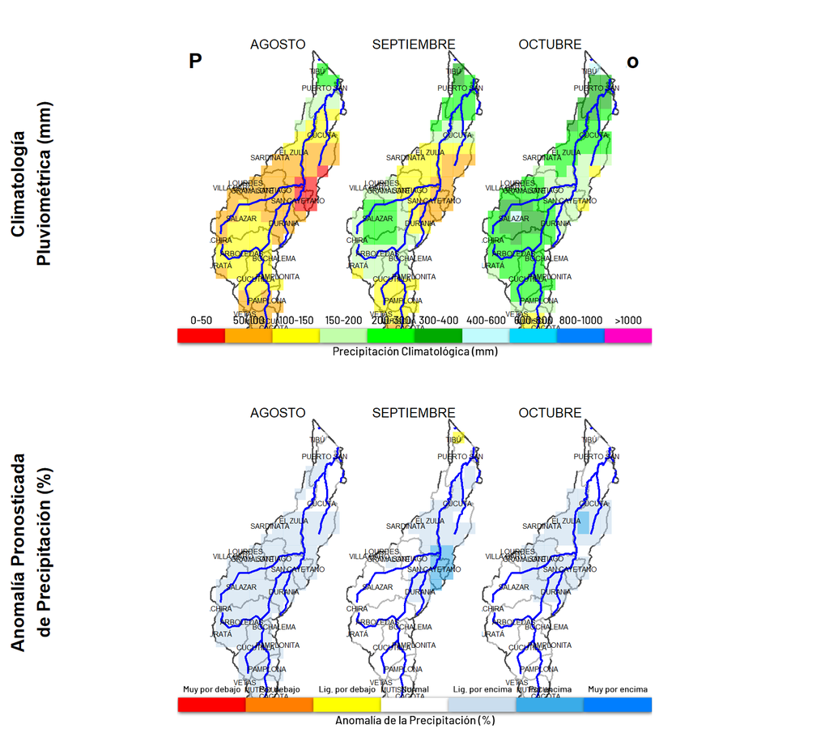

#### Análisis de cambios en la precipitación para la cuenca El Zulia, Norte de Santander

Las proyecciones de cambio en la precipitación acumulada para la cuenca El Zulia, durante el periodo de agosto de 2025 a enero de 2026, presentan un panorama de incrementos significativos.

En agosto de 2025, se prevé un **incremento moderado** del 16.8%, seguido por un aumento más leve en septiembre, con un 6.4%. Sin embargo, en octubre, se observará un **incremento moderado** del 8.7%, lo que sugiere una continuación de patrones húmedos en la región.

El mes de noviembre destaca con un **incremento considerable** del 27.7%, lo que podría tener un impacto notable en la disponibilidad de agua para los cultivos y ecosistemas locales. Diciembre también presenta un **incremento moderado** del 11.4%, seguido por un 15.9% en enero de 2026, lo que indica que la tendencia de aumento en la precipitación se mantendrá en los primeros meses del año.

En resumen, la cuenca El Zulia podría experimentar un periodo de lluvias más intensas, lo que podría tener repercusiones en la agricultura, especialmente en el cultivo de arroz, que depende de condiciones hídricas adecuadas. Será crucial monitorear estas tendencias para gestionar adecuadamente los recursos hídricos.

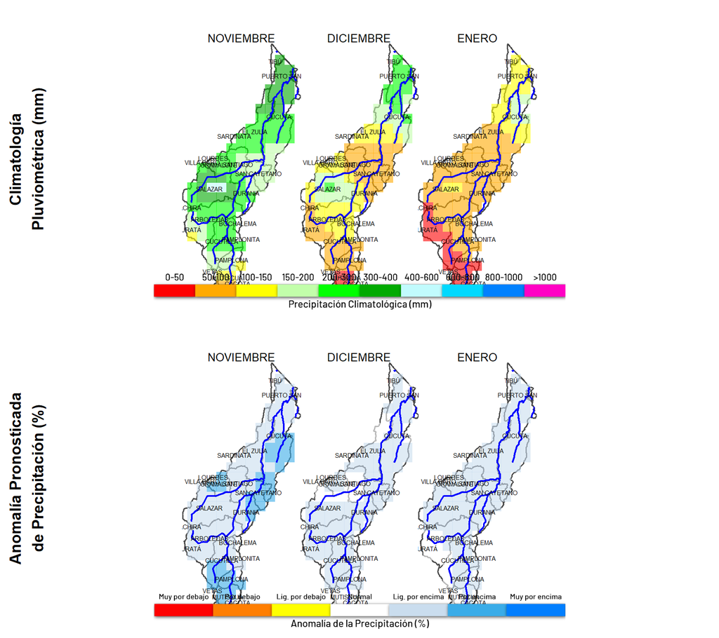

#### Pronóstico de Precipitación para la Cuenca El Zulia

Se prevé que la cuenca El Zulia, en Norte de Santander, experimente variaciones significativas en los volúmenes de lluvia durante los próximos meses. A continuación, se detallan las proyecciones:

- **Agosto 2025:** Los modelos indican que se pronostican **114.0 mm** de precipitación, con una probabilidad de acierto del **64%**. Aunque la probabilidad es moderada, existe un riesgo bajo de estrés hídrico, dado que las lluvias se mantienen en rangos aceptables.
- **Septiembre 2025:** Se anticipa un aumento en la precipitación, alcanzando **158.4 mm** con un **59%** de probabilidad de acierto. La fiabilidad es baja, por lo que la situación podría variar considerablemente.
- **Octubre 2025:** Se prevén **257.3 mm**, con una probabilidad de acierto del **58%**. La posibilidad de inundaciones aumenta si se superan los **300 mm**, aunque por ahora se mantiene dentro de un rango que podría ser manejable.
- **Noviembre 2025:** Los modelos indican un notable incremento, con **299.0 mm** y una probabilidad de acierto del **71%**. Este mes presenta un riesgo elevado de inundaciones si las precipitaciones superan las proyecciones.
- **Diciembre 2025:** Se pronostican **126.4 mm** de lluvia, con una probabilidad de acierto del **65%**. Es un mes más estable, pero sigue siendo necesario monitorear la situación.
- **Enero 2026:** Finalmente, se espera una reducción significativa a **79.0 mm**, con una probabilidad de acierto del **67%**. Esto podría llevar a situaciones de estrés hídrico, sobre todo si se considera una baja en las precipitaciones.

#### Conclusión

La fiabilidad de los pronósticos es variable, con algunas proyecciones más confiables que otras. La posibilidad de inundaciones es un riesgo significativo en noviembre, mientras que en enero podría surgir estrés hídrico si las lluvias se mantienen por debajo de los **50 mm**. Se recomienda seguir monitoreando las condiciones climáticas para una mejor gestión de recursos hídricos.

### Pronóstico de tiempo (7 dias)

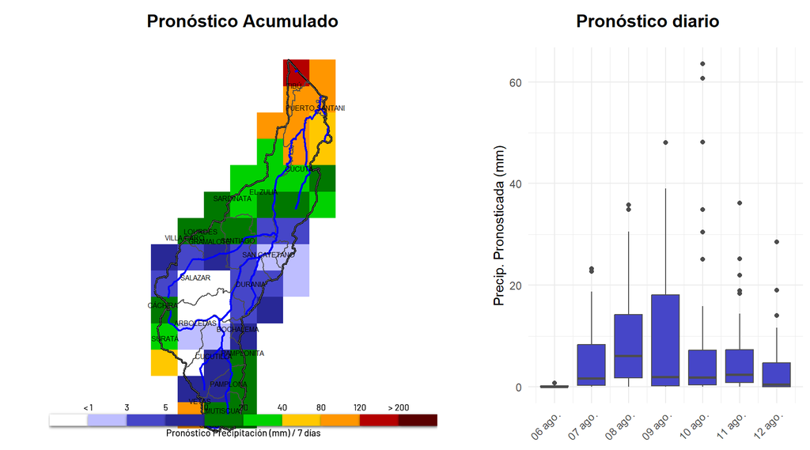

Para la cuenca **Cuenca_El-Zulia_Norte-de-Santander**, el pronóstico de precipitaciones para la próxima semana muestra variaciones significativas en los volúmenes esperados. El día 8 de agosto se anticipan volúmenes elevados, con acumulaciones que podrían alcanzar niveles intensos, lo que sugiere la posibilidad de inundaciones locales. El día 9 también se presenta con volúmenes intensos, aunque algo más moderados en comparación con el día anterior. Los días 7 y 10 de agosto se prevén volúmenes moderados, que podrían generar un impacto positivo en la agricultura local, dado que las lluvias son necesarias para el desarrollo de cultivos. Finalmente, el 11 de agosto se espera también un rango de volúmenes moderados, mientras que el día 12 podría traer lluvias leves.

Respecto a las probabilidades de tiempo húmedo, se observan altas probabilidades desde el 8 hasta el 12 de agosto, con un notable 85.3% de probabilidad de lluvias el día 8, lo que indica un alto riesgo de precipitaciones. Los días previos y posteriores también muestran buenas probabilidades de tiempo húmedo, aunque con algunas variaciones. En general, la cuenca experimentará una semana con condiciones mayormente húmedas, lo que es favorable para la agricultura, aunque se debe monitorear el potencial de lluvias intensas en los días críticos. (IDEAM - WRF COLOMBIA)

### Seguimiento Meteorológico

**Nota:** para esta cuenca no existe información meteorológica.

## Cuenca Rancheria - La Guajira

La cuenca del río Ranchería, ubicada en el departamento de La Guajira, abarca cerca de 2500 km² y comprende los municipios de San Juan del Cesar, La Jagua del Pilar, Distracción y parte de Hatonuevo. Nace en la falda sur de la Sierra Nevada de Santa Marta, a más de 1000 m s.n.m., y desciende hacia el norte hasta desembocar en el mar Caribe, conformando un valle semiárido clave para la región.

Agrícola y ganadera, la cuenca sostiene cultivos de ñame, maíz y sorgo en los valles irrigados, y extensiones de pastos para ganadería doble propósito. En laderas bajas se practican huertos familiares de hortalizas, mientras que en las zonas más altas y frescas se destinan pequeñas parcelas a frutales de clima templado.

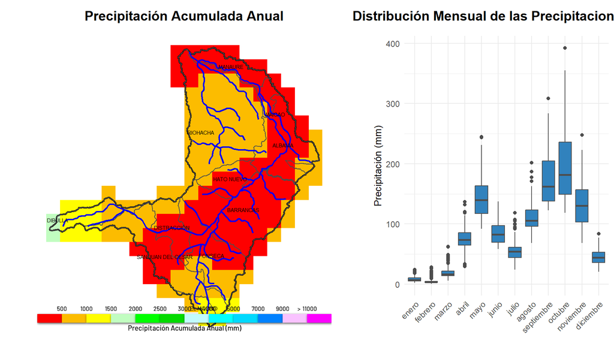

A partir de abril, las precipitaciones comienzan a aumentar, alcanzando su pico entre septiembre y octubre, donde se registran los valores más altos, con octubre mostrando una mediana de 181.8 mm. En agosto, las precipitaciones son relativamente limitadas, pero aumentan significativamente en septiembre y octubre, lo que es crucial para el desarrollo agrícola.

Para los productores, es fundamental aprovechar las lluvias de agosto a octubre para la siembra de cultivos que requieren mayor humedad. Sin embargo, deben estar alerta ante el riesgo de inundaciones en octubre, dado que es el mes de mayor precipitación. Las lluvias de noviembre y diciembre, aunque son menores, pueden ser utilizadas para cultivos de ciclo corto. En general, la planificación debe considerar el ciclo de lluvias para optimizar la producción agrícola en la cuenca Ranchería La Guajira.

### Predicción Climática (6 meses)

#### Análisis del comportamiento histórico de la precipitación en la cuenca Cuenca Ranchería La Guajira

La cuenca Cuenca Ranchería La Guajira presenta un régimen de lluvias que se caracteriza por una notable variabilidad a lo largo de los meses. En los próximos seis meses, se observa el siguiente comportamiento de las precipitaciones acumuladas:

- **Agosto**: 103.3 mm (bajo)
- **Septiembre**: 155.2 mm (normal)
- **Octubre**: 175.5 mm (normal)
- **Noviembre**: 133.0 mm (bajo)
- **Diciembre**: 42.6 mm (muy bajo)
- **Enero**: 7.2 mm (muy bajo)

Históricamente, los meses de mayor precipitación se concentran entre septiembre y octubre, donde las medianas superan los 150 mm, alcanzando un pico en octubre con 175.5 mm. Este volumen de lluvia se clasifica como normal, lo que indica una disponibilidad adecuada de agua en el sistema hídrico, favoreciendo la recarga de acuíferos y el suministro para actividades agrícolas, especialmente el cultivo de arroz.

Sin embargo, en diciembre y enero, las precipitaciones son considerablemente bajas, con valores de 42.6 mm y 7.2 mm, respectivamente, lo que resulta en condiciones muy críticas para los afluentes. Estas cifras indican un riesgo de disminución en los niveles de los ríos y un impacto negativo en la disponibilidad de agua para el riego y otras necesidades.

Es relevante destacar que ninguna de las medianas históricas supera los 300 mm, lo que sugiere que no se prevén riesgos inminentes de crecientes o desbordamientos en la cuenca. No obstante, el monitoreo continuo es fundamental, especialmente en los meses de transición hacia la temporada seca.

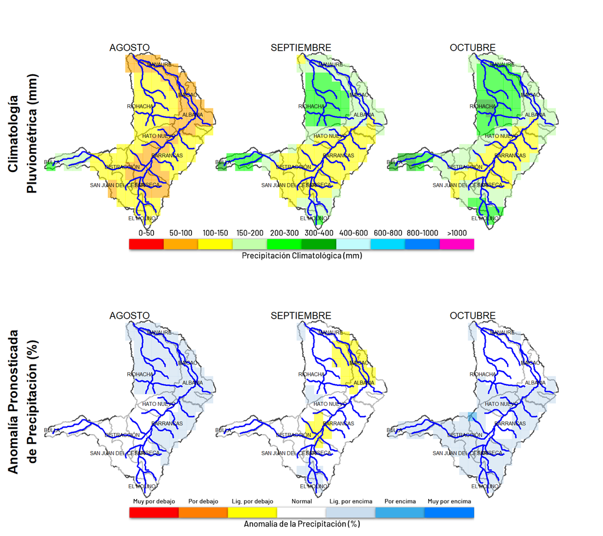

#### Análisis de Cambios en la Precipitación Acumulada para la Cuenca Ranchería, La Guajira

Para el periodo pronosticado entre agosto de 2025 y enero de 2026, se observan variaciones significativas en la precipitación acumulada en la cuenca Ranchería, La Guajira. En agosto de 2025, se prevé un **incremento moderado** del 13.1% en la precipitación, lo que podría favorecer el inicio de la temporada de lluvias. Sin embargo, en septiembre, se anticipa una **reducción ligera** del 1.0%, lo que podría afectar temporalmente la disponibilidad de agua para los cultivos.

A partir de octubre, las proyecciones indican un **incremento notable** del 13.3%, seguido por un **aumento significativo** del 43.0% en noviembre. Este último mes podría ser crucial para la recarga de los sistemas hídricos y el soporte a la agricultura local. En diciembre, se espera un **incremento moderado** del 21.5%, lo que continuaría beneficiando la actividad agrícola, especialmente para cultivos como el arroz.

Finalmente, en enero de 2026, el pronóstico muestra un **incremento fuerte** del 25.5%, lo que sugiere que las condiciones hídricas serán favorables al inicio del año. En resumen, las previsiones apuntan a un periodo de lluvias variable pero en general positivo para la cuenca Ranchería, con picos significativos que podrían impactar la producción agrícola en la región.

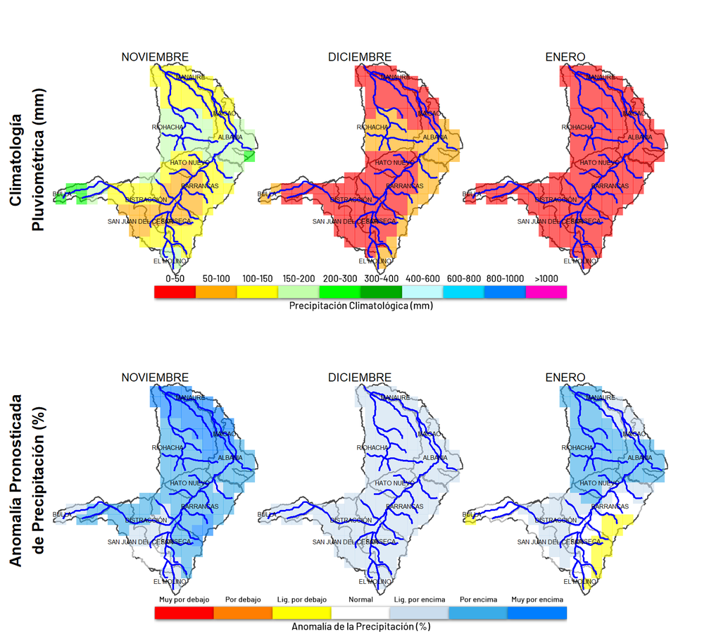

#### Pronóstico de Precipitación para la Cuenca Ranchería La Guajira

Se prevé que la cuenca Ranchería La Guajira experimente un aumento significativo en los volúmenes de precipitación en los próximos meses. Según los pronósticos, se anticipa que en agosto de 2025 caerán aproximadamente 116.5 mm de lluvia, con una probabilidad de acierto del 63%. Esta cantidad es un indicativo de un inicio de temporada húmeda, aunque la probabilidad de incertidumbre es moderada.

Para septiembre de 2025, los modelos indican un incremento a 151.9 mm, con una probabilidad de acierto del 54%, lo que sugiere una baja fiabilidad en este pronóstico. En octubre, se espera que las lluvias alcancen 201.3 mm, con una probabilidad de acierto del 60%, lo que nuevamente refleja una incertidumbre considerable en la estimación.

En noviembre, se prevé un aumento a 204.6 mm, con una probabilidad de acierto más alta del 72%, lo que indica que las lluvias podrían ser más consistentes. Sin embargo, si este volumen de lluvia se supera, podría haber un riesgo de inundaciones, especialmente si se alcanzan valores superiores a los 300 mm.

En diciembre, se anticipa una disminución notable de la precipitación a 52.0 mm, con un 69% de probabilidad de acierto, lo que podría generar estrés hídrico en la región. Finalmente, en enero de 2026, se prevé una caída a 8.8 mm, con una probabilidad de 68%, lo que refuerza la tendencia hacia condiciones más secas.

En resumen, aunque hay indicios de un aumento en la precipitación, la fiabilidad de los pronósticos es variable, y se deben considerar los riesgos asociados a inundaciones y estrés hídrico, especialmente en diciembre y enero.

### Pronóstico de tiempo (7 dias)

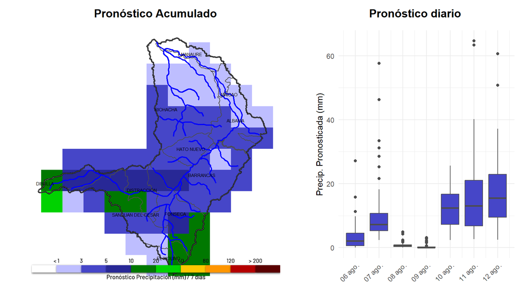

Para la cuenca **Cuenca_Rancheria_La-Guajira**, se prevén días con volúmenes de precipitación que varían en intensidad a lo largo de la semana. Los días 10, 11 y 12 de agosto se destacan con volúmenes elevados de lluvia, donde se anticipan precipitaciones intensas. En estos días, la mediana de precipitación sugiere que se pueden esperar acumulados significativos, lo que podría impactar las actividades agrícolas de la región. Por otro lado, el 6 de agosto también presenta un día con precipitaciones leves, mientras que el 7 de agosto se prevé un incremento considerable en la lluvia, con volúmenes que podrían considerarse moderados.

Sin embargo, hacia el final de la semana, el 8 y 9 de agosto se anticipan condiciones de sequía, con baja probabilidad de lluvia. En términos de probabilidades de tiempo húmedo, el 6 y el 7 de agosto muestran altas probabilidades, alcanzando el 100% el 7. Los días 8 y 9 presentan una considerable disminución en la probabilidad de lluvias, indicando que estos días serán mayormente secos. A partir del 10 de agosto, las probabilidades de tiempo húmedo vuelven a ser altas, cercano al 100%, lo que sugiere que la cuenca experimentará un cambio hacia condiciones más húmedas nuevamente.

(Retrieved from IDEAM - WRF COLOMBIA)

### Seguimiento Meteorológico

**Nota:** para esta cuenca no existe información meteorológica.

## Cuenca Ariguaní - Cesar

La cuenca sostiene cultivos de arroz, maíz y palma de aceite en sus extensas planicies aluviales, junto con horticultura y frutales en margen de ríos. La ganadería doble propósito es igualmente relevante, aprovechando pasturas naturales y praderas mejoradas. En las zonas altas de influencia de la serranía predominan bosques secos y relictos de bosque húmedo tropical, hábitat de especies endémicas y migratorias.

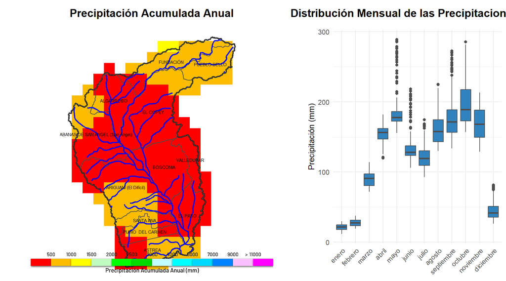

La cuenca Rio Ariguani Cesar presenta un comportamiento bimodal en su régimen pluviométrico, caracterizado por dos temporadas secas al año. Las temporadas de menor precipitación ocurren generalmente de enero a marzo y de julio a mediados de agosto. En los meses que se avecinan, se observa un aumento progresivo de las precipitaciones.

Históricamente, agosto muestra precipitaciones relativamente limitadas con una mediana de 157.8 mm, lo que indica una transición hacia un aumento en la actividad pluviométrica. Septiembre y octubre suelen ser los meses más lluviosos, con medianas de 171.7 mm y 188.9 mm, respectivamente. Noviembre también presenta precipitaciones significativas, aunque se reduce en comparación con octubre, con una mediana de 168.1 mm. Diciembre regresa a un patrón de bajas precipitaciones, afectando la disponibilidad de agua para cultivos.

Para los productores, es esencial estar preparados para la alta precipitación de septiembre y octubre, que podría generar riesgos de inundaciones y erosión del suelo. Se recomienda implementar prácticas de manejo de agua, como la construcción de drenes y la siembra de cultivos de cobertura. La planificación de cultivos debe considerar las temporadas secas y las lluvias, buscando variedades resilientes que se adapten a estos patrones climáticos.

### Predicción Climática (6 meses)

#### Análisis del comportamiento histórico de la precipitación en la cuenca Cuenca Rio Ariguani Cesar

La cuenca Cuenca Rio Ariguani Cesar presenta un régimen de lluvias caracterizado por variaciones significativas en las precipitaciones acumuladas a lo largo del año. Para los próximos seis meses, se observa lo siguiente:

- **Agosto**: 156.7 mm (Normal)
- **Septiembre**: 171.2 mm (Normal)
- **Octubre**: 187.1 mm (Normal)
- **Noviembre**: 166.5 mm (Normal)
- **Diciembre**: 40.7 mm (Muy bajo)
- **Enero**: 20.3 mm (Muy bajo)

Históricamente, los meses de agosto a noviembre muestran precipitaciones en el rango normal, con cifras que oscilan entre 156.7 mm y 187.1 mm. Esto indica un abastecimiento adecuado de agua para la cuenca, lo que es fundamental para el mantenimiento de los niveles de los ríos y la disponibilidad de agua para actividades agrícolas, especialmente el cultivo de arroz.

Sin embargo, en diciembre y enero, las precipitaciones caen drásticamente a niveles considerados muy bajos, con 40.7 mm y 20.3 mm, respectivamente. Estas cifras son críticas, ya que pueden llevar a niveles bajos y limitados en los afluentes, afectando tanto la disponibilidad de agua como el bienestar del ecosistema acuático.

No se reportan precipitaciones que superen los 300 mm en este período, lo que sugiere un riesgo reducido de crecientes y desbordamientos. Por lo tanto, la cuenca se enfrenta a un desafío en la transición hacia los meses secos, donde es crucial manejar adecuadamente los recursos hídricos para garantizar la sostenibilidad agrícola y el equilibrio ecológico.

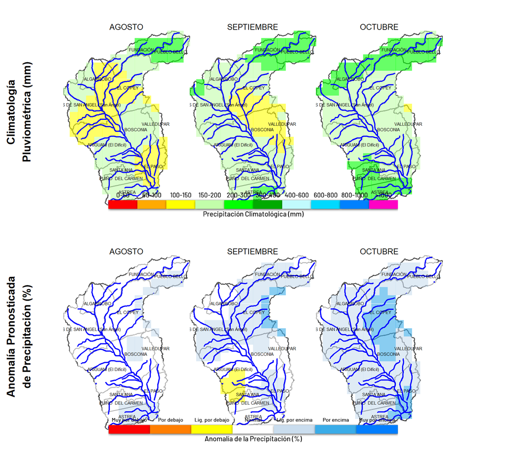

#### Análisis de Cambio de Precipitación en la Cuenca Río Ariguani, Cesar

Las proyecciones de cambio en la precipitación acumulada para la Cuenca Río Ariguani en Cesar indican un patrón de incremento moderado a significativo en los próximos meses. En agosto de 2025, se prevé un aumento del 8.0%, lo que sugiere un comienzo gradual en el incremento de las lluvias. Este patrón se intensifica en septiembre, donde el cambio se eleva a un 10.7%.

El mes de octubre de 2025 muestra un notable incremento del 20.5%, lo que indica una tendencia hacia un suministro hídrico más abundante en la cuenca. Sin embargo, el mes de noviembre es aún más crítico, con un aumento proyectado del 29.7%, lo que podría tener implicaciones significativas para la gestión de recursos hídricos y el cultivo de arroz en la región.

A partir de diciembre de 2025, se espera una leve desaceleración, con un cambio del 16.1%, y en enero de 2026, se proyecta una estabilización con un incremento del 6.8%. Estas tendencias sugieren que la Cuenca Río Ariguani experimentará un periodo de lluvias más intensas, lo que podría mejorar la disponibilidad de agua para los cultivos, pero también representa riesgos asociados a inundaciones y manejo del agua.

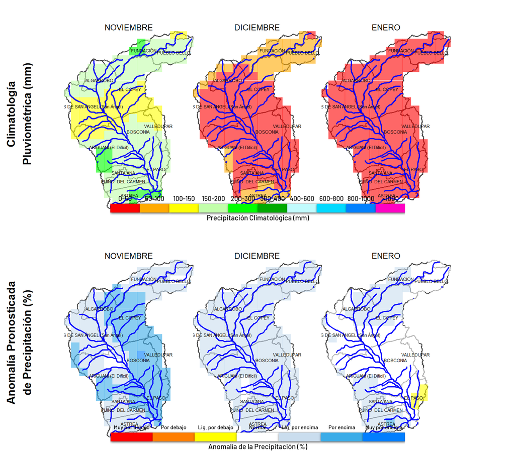

#### Evolución de la precipitación en la Cuenca Río Ariguani, Cesar

Se prevé que la cuenca del Río Ariguani experimentará variaciones significativas en los volúmenes de lluvia en los próximos meses. Según el pronóstico, para **agosto de 2025**, se anticipa una precipitación de **168.6 mm**, con una probabilidad de acierto del **60%**. Aunque esta cifra es considerable, la probabilidad de acierto indica que existe una baja certeza en el pronóstico.

Para **septiembre de 2025**, los modelos indican un incremento en la precipitación a **180.8 mm**, con una probabilidad de acierto del **59%**, lo que sugiere una situación similar en términos de confiabilidad. En **octubre**, se espera un aumento notable en los volúmenes de lluvia, alcanzando **229.1 mm** y una probabilidad de acierto del **67%**. Sin embargo, esta cifra aún no supera el umbral crítico de **300 mm**, que podría generar inundaciones.

En **noviembre de 2025**, los pronósticos sugieren precipitaciones de **221.5 mm**, con una probabilidad de acierto del **73%**, lo que indica una mayor confiabilidad en comparación con los meses anteriores. No obstante, en **diciembre** se anticipa un drástico descenso a **46.4 mm** (65% de probabilidad), lo que podría llevar al estrés hídrico en la región, especialmente considerando que esta cifra está por debajo del umbral crítico de **50 mm**.

Finalmente, en **enero de 2026**, se prevé una precipitación de **22.7 mm** con un **67% de probabilidad**, lo que refuerza la posibilidad de estrés hídrico para los cultivos y ecosistemas locales. En resumen, aunque hay incertidumbres en los pronósticos, la región debe prepararse para fluctuaciones significativas en la disponibilidad de agua, lo que podría afectar los cultivos y la gestión de recursos hídricos.

### Pronóstico de tiempo (7 dias)

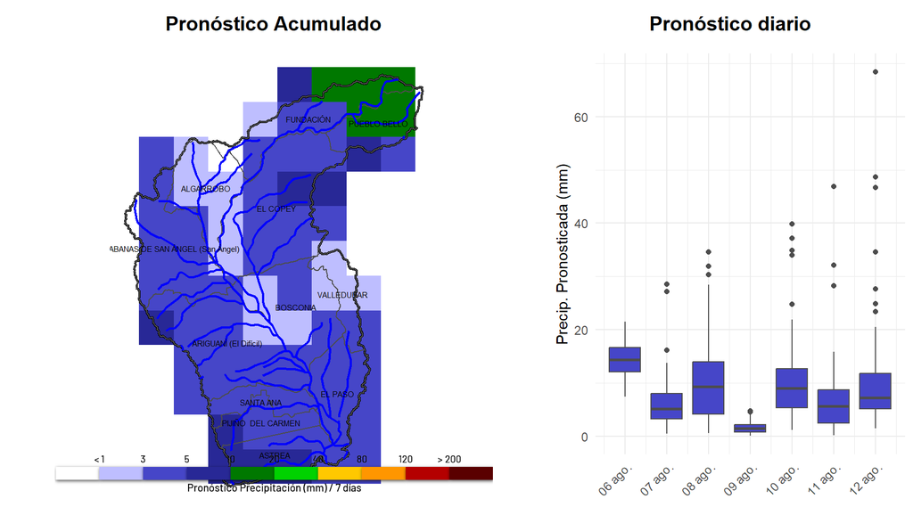

Para la cuenca **Cuenca_Rio-Ariguani_Cesar**, se anticipa una semana con variabilidad en las precipitaciones. Los días con mayores volúmenes esperados son el 6 de agosto y el 8 de agosto, donde se prevén volúmenes elevados. Estos días presentan intensidades de precipitaciones intensas, con medianas que sugieren una acumulación significativa. Por otro lado, el 10 de agosto también se espera un volumen elevado, manteniendo la tendencia de precipitaciones intensas.

El 7 de agosto y el 11 de agosto se caracterizan por volúmenes moderados, donde las precipitaciones se mantienen en niveles que podrían ser beneficiosos para el desarrollo agrícola sin generar un exceso que cause problemas de escorrentía. El 9 de agosto se prevé un día con volúmenes bajos, donde la lluvia esperada es mínima, sugiriendo un respiro en las condiciones húmedas de la cuenca. Finalmente, el 12 de agosto se anticipan volúmenes elevados nuevamente, con precipitaciones intensas que podrían contribuir a la recarga de los cuerpos de agua.

Las probabilidades de tiempo húmedo para la cuenca son altas a lo largo de toda la semana. En la mayoría de los días, las proyecciones indican que hay altas probabilidades de que se registre lluvia, con cifras cercanas al 100% en varios de ellos, lo que sugiere condiciones predominantemente húmedas. Estos patrones son relevantes para la planificación agrícola y la gestión del agua en la región. (IDEAM - WRF COLOMBIA)

### Seguimiento Meteorológico

**Nota:** para esta cuenca no existe información meteorológica.

## Cuenca Río Cesar - Cesar

La cuenca del río Cesar, ubicada en el corazón del departamento del Cesar, se extiende por cerca de 13000 km² e incluye los municipios de Valledupar, Bosconia, Chimichagua, El Copey, La Paz y Manaure, entre otros. Nace en la Serranía de Los Motilones, a más de 1500 m s.n.m., y recorre valles amplios de clima tropical seco y semiárido antes de confluir con la Ciénaga de Zapatosa.

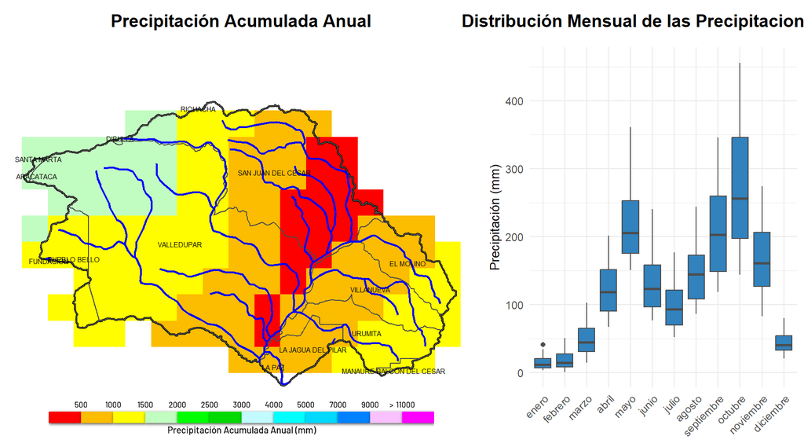

La cuenca Rio Cesar presenta un régimen bimodal, caracterizado por dos temporadas secas al año. Las temporadas de menor precipitación se registran de enero a marzo y de julio a agosto, lo que resalta la variabilidad estacional de las lluvias en esta región.

Históricamente, los meses de agosto a diciembre muestran un comportamiento notable en cuanto a precipitaciones. En agosto, las lluvias son relativamente limitadas con una mediana de 144.7 mm, mientras que septiembre y octubre son meses de precipitaciones adecuadas, alcanzando 202.4 mm y 256.1 mm respectivamente. Noviembre también presenta precipitaciones relativamente limitadas (160.6 mm), y diciembre inicia una reducción abrupta con valores de 40.7 mm, marcando el fin del ciclo lluvioso.

Para los productores, es crucial considerar que, aunque septiembre y octubre ofrecen condiciones favorables para el crecimiento de cultivos, noviembre y diciembre presentan un riesgo de sequía, lo cual puede afectar la planificación de siembras. Por lo tanto, se recomienda realizar actividades agrícolas que aprovechen las lluvias de septiembre y octubre, mientras que en noviembre y diciembre se debe considerar la posibilidad de riego o seleccionar cultivos que toleren condiciones de sequía.

### Predicción Climática (6 meses)

#### Análisis del comportamiento histórico de la precipitación en la cuenca Cuenca Rio Cesar

El régimen de lluvias en la cuenca Rio Cesar presenta un comportamiento característico en los próximos seis meses. Históricamente, se ha observado una mediana de precipitación que varía significativamente de mes a mes. Para agosto, la mediana es de 142.4 mm, lo que indica niveles de lluvia en la categoría “normal”, contribuyendo a un adecuado nivel de agua en los afluentes. Sin embargo, en septiembre, la mediana aumenta a 201.2 mm, manteniéndose en la misma categoría, lo que favorece un buen abastecimiento hídrico, crucial para las actividades agrícolas en la región.

Octubre es el mes con la mayor mediana de precipitación, alcanzando 255.9 mm, lo que lo clasifica como “normal”, aunque ya se aproxima al umbral de “intenso”. Este aumento en las precipitaciones puede generar un mayor caudal en los ríos, lo que es beneficioso para la recarga de acuíferos, pero también puede presentar riesgos de crecientes si las lluvias son excesivas.

En noviembre, la mediana desciende a 166.2 mm, manteniendo un nivel “normal” que sigue siendo favorable. En diciembre, se observa un notable descenso a 40.3 mm, lo que entra en la categoría de “muy bajo”, lo que puede llevar a niveles críticos en los afluentes y afectar la disponibilidad de agua para el inicio del año siguiente. Finalmente, enero presenta una mediana de solo 12.1 mm, también dentro del rango de “muy bajo”, lo que podría agravar aún más la situación hídrica en la cuenca.

En resumen, mientras que los meses de agosto a noviembre presentan una precipitación adecuada y beneficiosa para la agricultura, diciembre y enero muestran un descenso crítico en las lluvias, lo que podría impactar negativamente en el nivel del río y la disponibilidad de agua en la cuenca.

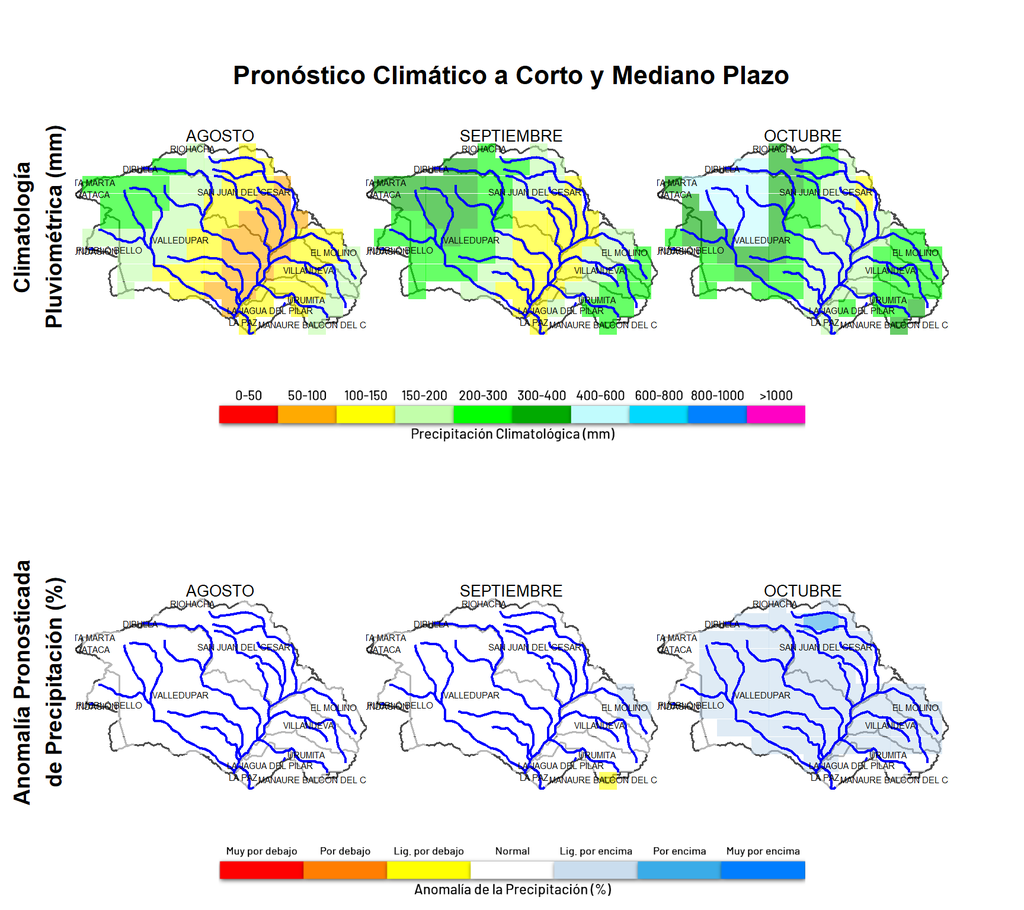

#### Análisis de Cambios en la Precipitación para la Cuenca Río Cesar

Las proyecciones de cambio en la precipitación acumulada para la cuenca Río Cesar muestran una tendencia variable a lo largo de los meses pronosticados. En agosto de 2025, se anticipa un incremento moderado del 5.1%, lo que sugiere que las condiciones hídricas podrían ser favorables para el inicio de la temporada de lluvias. Sin embargo, en septiembre, el aumento es más modesto, con solo un 1.2%.

A partir de octubre, se prevé un notable aumento en la precipitación, con un cambio del 16.5%. Este patrón se acentúa en noviembre, donde se espera un incremento considerable del 19.3%, lo que podría tener un impacto positivo en la agricultura, especialmente en cultivos como el arroz. En diciembre, el pronóstico indica una reducción en el ritmo de crecimiento, aunque aún se espera un aumento del 12.4%.

Finalmente, en enero de 2026, se proyecta una reducción del 4.8%, lo que podría indicar un regreso a condiciones más secas después de un período de lluvias intensas. En general, la cuenca Río Cesar experimentará un ciclo de lluvia significativo, con una fase de incremento que beneficiará la agricultura, seguido de una ligera reducción que deberá monitorearse de cerca.

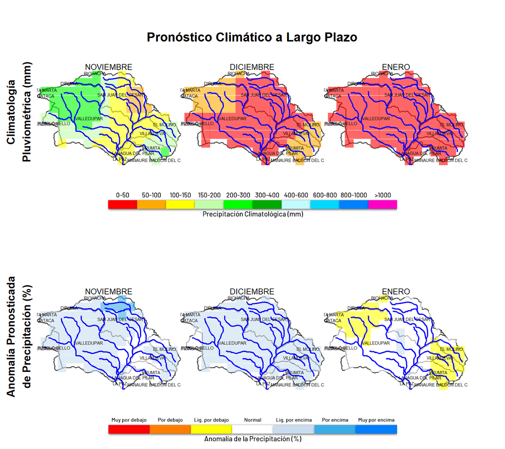

#### Pronóstico de Precipitación para la Cuenca Río Cesar

Se prevé que los volúmenes de precipitación en la cuenca Río Cesar experimenten variaciones significativas en los próximos meses. Según los pronósticos, se anticipa que en agosto de 2025 se registren aproximadamente 150.5 mm de lluvia, con una probabilidad de acierto del 58%. Esto indica que la certeza sobre esta cantidad de precipitación es muy baja, lo que podría llevar a un escenario de estrés hídrico si las lluvias se mantienen por debajo de los 50 mm.

Para septiembre, los modelos indican un incremento considerable en la precipitación, alcanzando un estimado de 203.6 mm, aunque la probabilidad de acierto se mantiene en un 57%. Esta cantidad, aunque no crítica, seguirá siendo un factor importante para la agricultura local.

En octubre, se anticipa un notable aumento, con 298.7 mm pronosticados y una probabilidad de acierto del 63%. Este nivel es preocupante, ya que podría acercarse al umbral de inundaciones si se superan los 300 mm.

Sin embargo, en noviembre, la situación se estabiliza con 193.6 mm pronosticados y una probabilidad de acierto del 65%, lo que sugiere un retorno a condiciones más manejables, aunque aún con riesgo de inundaciones.

Finalmente, en diciembre y enero, se espera una drástica reducción en las precipitaciones, con 46.5 mm y 11.1 mm, respectivamente, ambos con una probabilidad de acierto del 65%. Esta disminución podría generar un estrés hídrico significativo en la región, afectando los cultivos, especialmente el arroz.

En conclusión, la fiabilidad del pronóstico es moderada, especialmente en los meses de mayor precipitación, donde la probabilidad de acierto se sitúa entre el 57% y el 65%. Es esencial que los agricultores y gestores de cuenca se preparen para estas fluctuaciones y mantengan estrategias de manejo del agua adecuadas.

### Pronóstico de tiempo (7 dias)

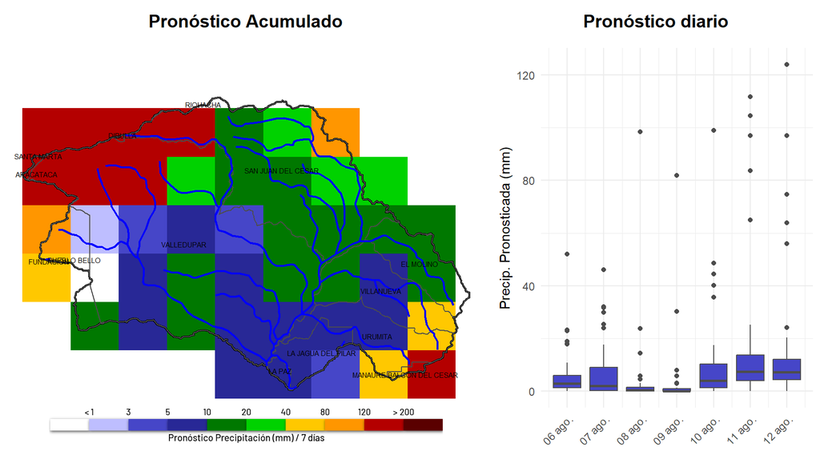

Para la cuenca **Cuenca_Rio-Cesar_Cesar**, se anticipan días con diferentes volúmenes de precipitación en la próxima semana. Se prevé que los días 11 y 12 de agosto presenten volúmenes elevados de precipitación, con intensidades clasificadas como precipitaciones intensas. Esto significa que las lluvias podrían ser significativas, lo que podría influir en el manejo agrícola y en la disponibilidad de agua en la cuenca.

El 10 de agosto también se espera que haya volúmenes moderados de precipitación, lo que podría contribuir a un suelo húmedo, favoreciendo ciertos cultivos. Sin embargo, los días 8 y 9 de agosto no mostrarán precipitaciones significativas, con pronósticos que sugieren un tiempo seco predominante, lo que podría ser ventajoso para actividades agrícolas que requieren condiciones de suelo secas.

En términos de probabilidad de tiempo húmedo, el 6 y el 10 de agosto muestran altas probabilidades de que más del 80% de los puntos experimenten lluvias. Además, los días 11 y 12 también presentan altas probabilidades de tiempo húmedo, superando el 90%, lo que sugiere que la cuenca podría recibir lluvias consistentes durante estos días. En resumen, se anticipa un inicio de semana variable, con un aumento de lluvias hacia el fin de semana, lo que es relevante para la planificación agrícola.

(IDEAM - WRF COLOMBIA)

### Seguimiento Meteorológico

**Nota:** para esta cuenca no existe información meteorológica.

# Cuencas Caribe Húmedo

## Cuenca Río Sinú

La cuenca del río Sinú, en el departamento de Córdoba, abarca aproximadamente 25000 km² y atraviesa municipios como Montería, Lorica, Sahagún, Planeta Rica y Ciénaga de Oro. Su nacimiento se ubica en la vertiente occidental de la Serranía de San Jerónimo, a más de 1000 m s.n.m., y desemboca en el golfo de Morrosquillo, en el mar Caribe.

En términos productivos, la cuenca sostiene sistemas de riego para arroz, maíz y palma de aceite, así como extensas áreas de ganadería bovina. Su red de canales, represas y sistemas de derivación ha permitido ampliar la superficie de cultivos durante la estación seca, mitigando los riesgos de déficit hídrico.

Desde el punto de vista ambiental, el Sinú nutre humedales y ciénagas (Ciénaga de Betancí y Los Tigres), esenciales para la biodiversidad de aves acuáticas y peces de agua dulce. Los esfuerzos de gestión se centran en el monitoreo de la calidad del agua, la restauración de franjas ribereñas y la gobernanza intermunicipal, con el fin de equilibrar la seguridad hídrica, la productividad agrícola y la conservación de sus ecosistemas.

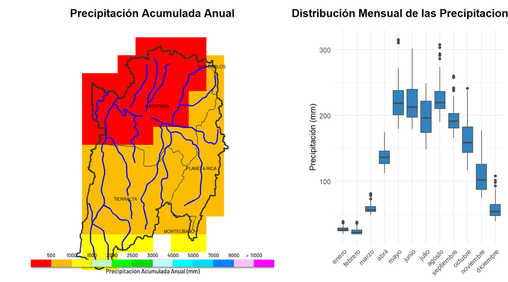

En la cuenca Sinu Córdoba, el comportamiento histórico de las precipitaciones en los meses de agosto a enero muestra variabilidad significativa. Agosto es un mes de precipitaciones adecuadas con una mediana de 219.7 mm, lo que favorece la siembra de cultivos como maíz y caña de azúcar. Septiembre, aunque con precipitaciones relativamente limitadas (191.4 mm), aún ofrece condiciones favorables para el crecimiento de cultivos. Sin embargo, en octubre, las precipitaciones también son relativamente limitadas (159.1 mm), lo que puede generar estrés hídrico en los cultivos.

Noviembre presenta una disminución adicional en la precipitación (102.3 mm) y diciembre se caracteriza por precipitaciones muy bajas (54.2 mm), marcando el inicio de la estación seca. Este período seco puede representar un riesgo para los cultivos que requieren riego adicional.

Enero mantiene esta tendencia de baja pluviosidad (26.6 mm), lo que refuerza la necesidad de estrategias de manejo del agua para la producción agrícola.

### Predicción Climática (6 meses)

#### Análisis del comportamiento histórico de la precipitación en la cuenca Cuenca Sinu Córdoba

El régimen de lluvias en la cuenca Cuenca Sinu Córdoba muestra variaciones significativas a lo largo de los próximos seis meses. Históricamente, se han registrado las siguientes precipitaciones acumuladas (mediana en mm):

- **Agosto:** 218.2 mm
- **Septiembre:** 188.6 mm
- **Octubre:** 159.5 mm
- **Noviembre:** 100.4 mm
- **Diciembre:** 52.4 mm
- **Enero:** 25.3 mm

Durante los meses de agosto, septiembre y octubre, la cuenca experimenta un patrón de lluvias normales a intensas, con precipitaciones que oscilan entre 159.5 mm y 218.2 mm. Estos niveles de lluvia son cruciales para la recarga de acuíferos y el mantenimiento del caudal de los ríos, favoreciendo la disponibilidad de agua para la agricultura y otros usos.

Sin embargo, a partir de noviembre, se observa una notable disminución en las precipitaciones, con noviembre alcanzando 100.4 mm, lo que se considera un nivel bajo. En diciembre, las lluvias caen drásticamente a 52.4 mm, clasificándose como muy bajo, lo que podría generar preocupaciones sobre los niveles críticos de los afluentes. Finalmente, en enero, la mediana se reduce aún más a 25.3 mm, indicando condiciones extremadamente secas.

Ninguna de las mediciones supera los 300 mm, lo que implica que no hay riesgo de desbordamientos en este periodo. Sin embargo, las precipitaciones por debajo de 100 mm en diciembre y enero pueden impactar negativamente en la disponibilidad de agua y en los cultivos, especialmente en el caso del arroz, que depende de un suministro adecuado de agua. Este comportamiento histórico debe ser considerado en la planificación agrícola y la gestión del agua en la región.

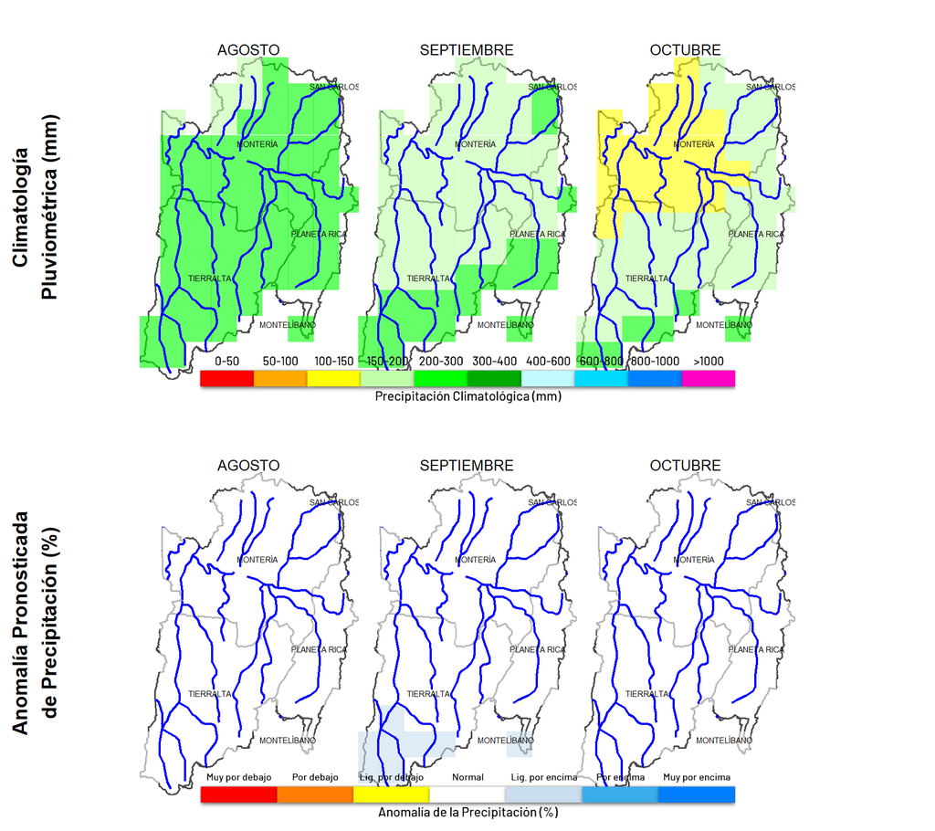

#### Análisis de Cambios en la Precipitación para la Cuenca Sinú Córdoba

Las proyecciones de cambio en la precipitación acumulada para la cuenca Sinú Córdoba entre agosto de 2025 y enero de 2026 muestran una tendencia creciente significativa. En los primeros meses, el cambio pronosticado es relativamente bajo, con un incremento moderado del 1.2% en agosto y un leve aumento del 0.7% en septiembre. Sin embargo, a medida que se avanza hacia el final del año, se observa un cambio notable.

Para octubre, se prevé un aumento más significativo del 2.3%. Este patrón de incremento se intensifica considerablemente en noviembre, con un cambio del 9.0%, y se eleva aún más en diciembre, alcanzando un 12.5%. Finalmente, en enero de 2026, el pronóstico indica un cambio del 13.6%, lo que sugiere un aumento considerable en la precipitación.

En resumen, las previsiones sugieren que la cuenca Sinú Córdoba experimentará un incremento progresivo en la precipitación acumulada, particularmente en el último trimestre de 2025 y el inicio de 2026. Esto podría tener implicaciones importantes para la gestión hídrica y el cultivo de arroz en la región, dado que una mayor disponibilidad de agua puede influir en los rendimientos agrícolas.

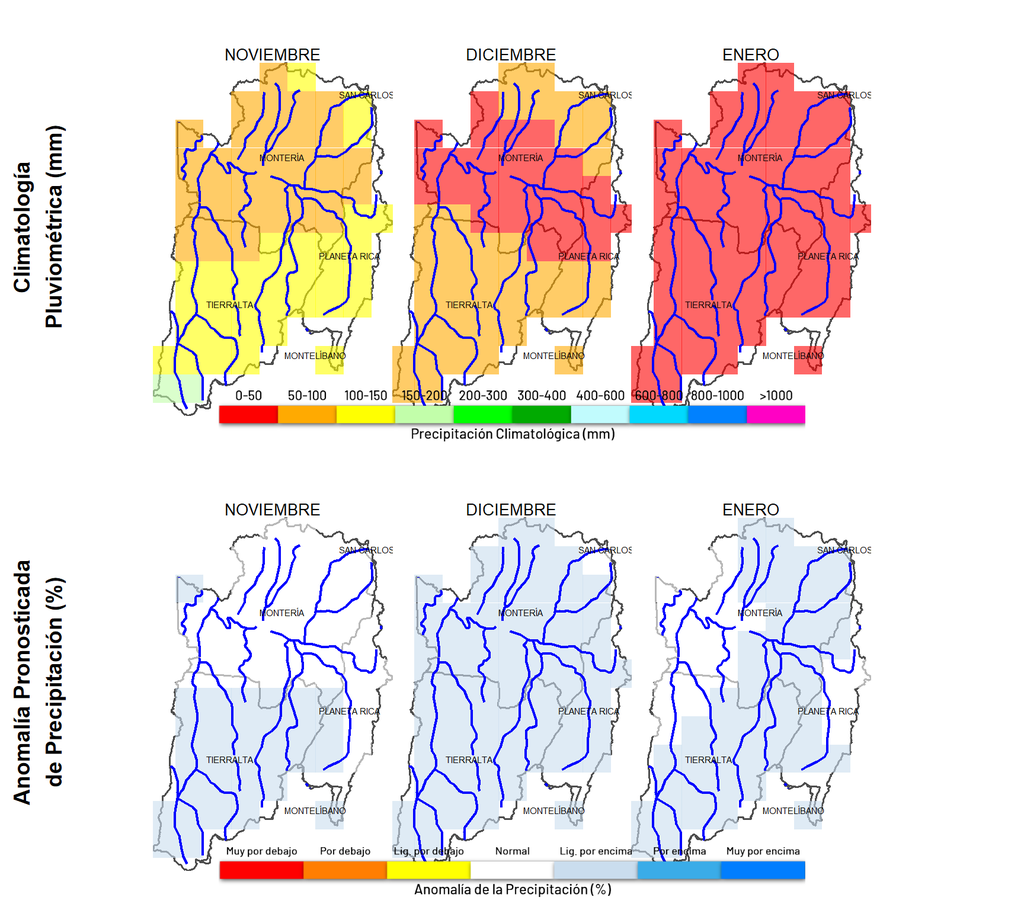

#### Pronóstico de Precipitación para la Cuenca Sinu Córdoba

Se prevé que la cuenca Sinu Córdoba experimentará una evolución significativa en los volúmenes de lluvia a lo largo de los próximos meses. Según los modelos de pronóstico:

- Para **agosto de 2025**, se anticipa un total de **221.5 mm** de precipitación, con una probabilidad de acierto del **56%**. Este volumen de lluvia podría generar riesgos de inundaciones si se superan los **300 mm**.
- En **septiembre**, se pronostica una reducción a **189.7 mm**, con una probabilidad de acierto del **54%**. A pesar de esta disminución, aún existe un riesgo de inundaciones si se alcanzan valores elevados.
- Para **octubre**, la tendencia de disminución continúa con **164.4 mm** previstos, y una probabilidad de acierto del **55%**, lo que indica que la fiabilidad del pronóstico sigue siendo moderada.
- En **noviembre**, los volúmenes de lluvia se prevén en **107.5 mm** con una probabilidad de acierto del **60%**. Esta cantidad, aunque menor, puede ser suficiente para causar estrés hídrico si se presentan condiciones de sequía.
- Para **diciembre**, se espera una drástica caída a **59.7 mm** y una probabilidad de acierto del **65%**, lo que sugiere que el riesgo de estrés hídrico aumentará si la precipitación se mantiene por debajo de **50 mm**.
- Finalmente, en **enero de 2026**, se anticipa un total de **27.3 mm**, con un 63% de probabilidad de acierto. Este volumen plantea un alto riesgo de estrés hídrico para los cultivos si las condiciones no mejoran.

En conclusión, la fiabilidad del pronóstico oscila entre un rango moderado a bajo, indicando que hay una necesidad de monitoreo constante debido a la probabilidad de precipitaciones que varían significativamente.

### Pronóstico de tiempo (7 dias)

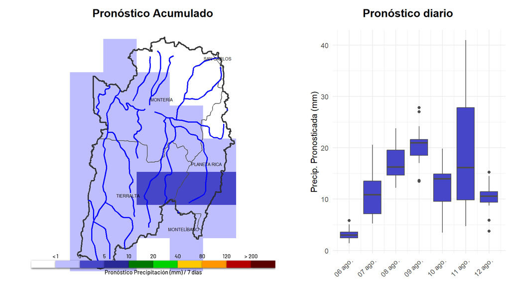

### Seguimiento Meteorológico

**Nota:** para esta cuenca no existe información meteorológica.

## Cuenca Río San Jorge

La cuenca del río San Jorge nace en el Parque Nacional Natural Paramillo, en la cordillera Occidental (municipios de Ituango-Antioquia y Montelíbano-Córdoba), y discurre en sentido sur-norte entre las serranías de San Jerónimo y Ayapel. Gran parte de su recorrido atraviesa el sudeste del departamento de Córdoba, hasta confluir con el río Cauca en el sur de Sucre, en la Depresión Momposina.

Su cuenca hidrográfica abarca unos 96 500 km² y se extiende por los departamentos de Córdoba, Sucre y Bolívar. Limita al oeste con la cuenca del río Sinú —separada por la Serranía de San Jerónimo—, al este con la cuenca del río Cauca —definida por la Serranía de Ayapel—, y al norte se abre hacia las planicies inundables de La Mojana en la Depresión Momposina.

El río recorre aproximadamente 368 km y su régimen hídrico oscila entre un caudal mínimo de 24 m³/s y uno máximo de 697 m³/s. Sus principales afluentes en Córdoba son los ríos San Pedro, Sucio y Uré. En la parte alta domina un relieve montañoso; en el tramo medio se desarrollan valles aluviales con suelos fértiles y humedales (ciénaga de Ayapel); y en la zona baja prevalecen extensas planicies e inundaciones periódicas en la Depresión Momposina.

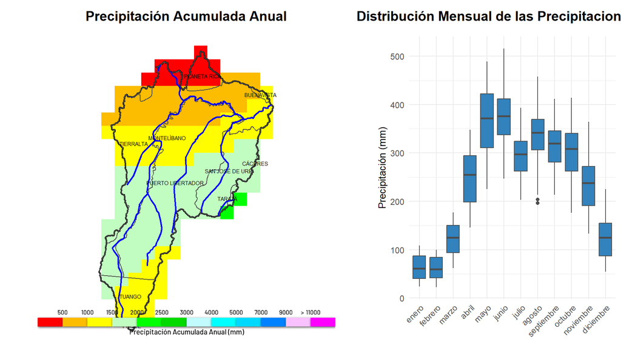

La cuenca San Jorge Córdoba presenta un régimen pluviométrico monomodal, caracterizado por una única estación seca al año y una marcada concentración de precipitaciones en los meses de mayor pluviosidad. Esta estación seca ocurre principalmente en los meses de enero y febrero, donde las precipitaciones son significativamente más bajas, con acumulados en torno a 61.2 mm y 59.9 mm, respectivamente.

Sin embargo, los productores deben estar atentos a los riesgos de inundaciones y erosión en esta época de intensas lluvias. Se recomienda implementar prácticas de conservación de suelos y adecuar sistemas de drenaje para mitigar estos efectos. La planificación de cultivos debe considerar estas tendencias, asegurando que las especies elegidas sean adecuadas para las condiciones de alta humedad y evitando siembras durante los picos de precipitación.

### Predicción Climática (6 meses)

#### Análisis del comportamiento histórico de la precipitación en la cuenca Cuenca San Jorge Córdoba

El régimen de lluvias en la cuenca Cuenca San Jorge Córdoba presenta un comportamiento característico a lo largo de los próximos seis meses, con variaciones significativas en la precipitación. Históricamente, se observa que en agosto, la mediana de precipitación alcanza los 338.6 mm, lo que indica un período de lluvias intensas. Este nivel de precipitación se clasifica como “intenso”, lo que conlleva un riesgo elevado de crecientes y desbordamientos en los ríos y quebradas de la región.

Durante septiembre, la mediana de 314.1 mm continúa reflejando condiciones de lluvias intensas, lo que puede impactar negativamente en la disponibilidad de agua y generar inundaciones en áreas vulnerables. En octubre, la precipitación se mantiene en un nivel elevado con 304.5 mm, lo que refuerza la tendencia de un clima húmedo en esta cuenca.

A partir de noviembre, la situación comienza a cambiar, ya que la mediana de precipitación desciende a 233.2 mm, lo que se considera “normal”. Este nivel, aunque más bajo, aún puede influir en los niveles de agua de los afluentes, pero con menos riesgo de desbordamientos. En diciembre, la mediana baja considerablemente a 117.2 mm, lo que indica un régimen de lluvias bajo, afectando potencialmente la disponibilidad de agua en la cuenca para actividades agropecuarias.

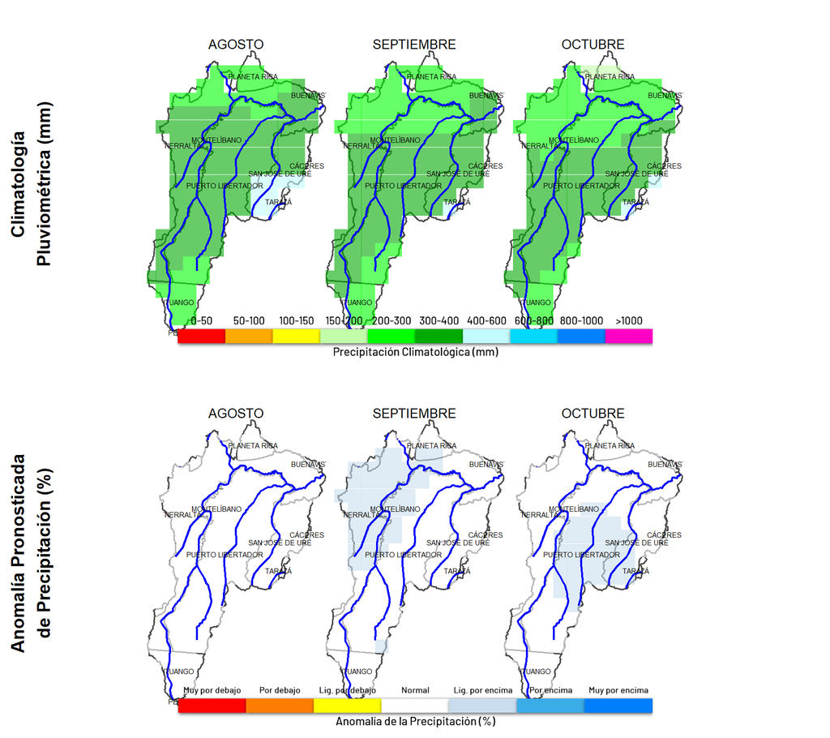

#### Análisis de Cambios en la Precipitación para la Cuenca San Jorge Córdoba

Esta serie de cambios sugiere que la cuenca experimentará un aumento consistente en la precipitación, lo que podría tener implicaciones importantes para la agricultura, especialmente en el cultivo de arroz, que es sensible a los patrones de lluvia. La gestión adecuada del agua será crucial para aprovechar estos incrementos y mitigar posibles impactos negativos, como inundaciones o erosión del suelo. Es fundamental que los agricultores y responsables de la gestión de recursos hídricos se preparen para estos cambios en las condiciones climáticas.

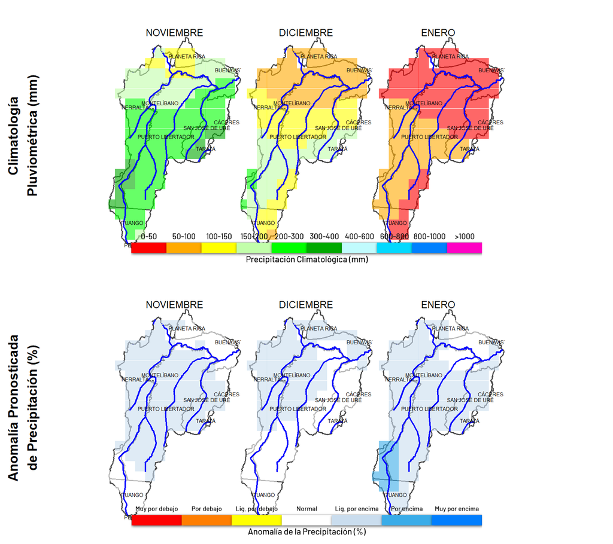

#### Evolución de la precipitación en la Cuenca San Jorge Córdoba

Se prevé que la cuenca San Jorge en Córdoba experimentará una notable variabilidad en los volúmenes de lluvia a lo largo de los próximos meses. Según el pronóstico, para agosto de 2025, se anticipa una precipitación de **349.4 mm**, con una probabilidad de acierto del **54%**. Esta cantidad de lluvia representa un riesgo significativo de inundaciones, dado que supera el umbral de **300 mm**.

En septiembre, se pronostica una ligera disminución a **334.8 mm** con una probabilidad de acierto del **58%**, lo que aún mantiene el riesgo de inundaciones. Durante octubre, la tendencia continúa con **329.9 mm** pronosticados y una probabilidad del **59%** de que se cumpla, lo que aumenta la inquietud por posibles eventos de agua acumulada.

Ya en noviembre, se espera una reducción considerable en la precipitación a **262.9 mm**, con una probabilidad de acierto del **67%**, que aunque es más alta, sigue siendo un volumen significativo que podría causar problemas si se producen lluvias concentradas. En diciembre, el pronóstico baja a **128.2 mm** con un **64%** de probabilidad de acierto, lo que reduce el riesgo de inundaciones, pero puede todavía generar estrés hídrico en áreas vulnerables.

### Pronóstico de tiempo (7 dias)

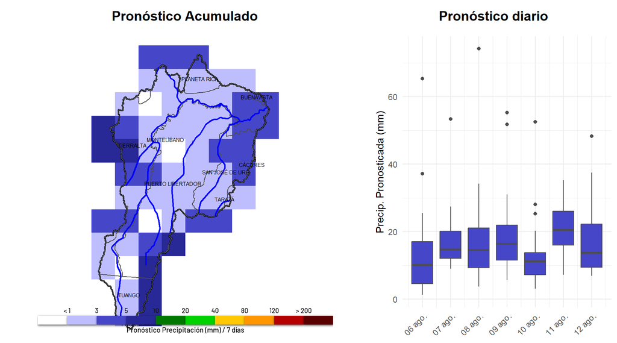

Para la cuenca **Cuenca_San-Jorge_Cordoba**, la próxima semana se prevén volúmenes de precipitación que se pueden clasificar como elevados a intensos, con días específicos destacándose por sus mayores acumulaciones. El día 11 de agosto se espera el volumen más alto, con un rango que podría considerarse elevado. Los días 6, 7, 8, y 9 de agosto también presentarán volúmenes significativos, donde se anticipan precipitaciones intensas, aunque ligeramente inferiores que el día 11. El día 10 de agosto podría ofrecer un respiro, con volúmenes moderados, pero aún así significativos, antes de que nuevamente se intensifiquen las precipitaciones el 12 de agosto, donde se pronostican volúmenes elevados.

En cuanto a las probabilidades de tiempo húmedo, se indica una alta probabilidad cercana al 100% de que se presenten lluvias a lo largo de toda la semana, lo que sugiere una condición continua de humedad en la cuenca. Esta situación puede ser favorable para los cultivos que requieren riego, pero también implica el riesgo de escorrentías y posibles inundaciones si las lluvias son muy intensas y prolongadas. Es recomendable que los agricultores estén atentos a estas condiciones para tomar decisiones oportunas en sus labores. (IDEAM - WRF COLOMBIA)

### Seguimiento Meteorológico

**Nota:** para esta cuenca no existe información meteorológica.

## Cuenca Nechí - Antioquia

La cuenca del río Nechí, ubicada en la subregión del Bajo Cauca antioqueño, abarca aproximadamente 10500 km² y forma parte de la cuenca mayor del río Cauca. Nace en la vertiente occidental de la Cordillera Central, en los municipios de Yarumal y Anorí, y desemboca en el río Cauca cerca de Tarazá. En su recorrido atraviesa o drena territorios de municipios como Nechí, El Bagre, Zaragoza, Caucasia y Tarazá.

Económicamente la región combina la agricultura (principalmente palma de aceite, arroz y plátano) con la ganadería extensiva y la minería aurífera a pequeña escala, que históricamente ha generado retos de contaminación por sedimentos y mercurio en el río. Su red fluvial es además hábitat importante para peces de interés comercial (bagres y bocachicos) y aves acuáticas.

La cuenca del Nechí juega un papel fundamental en la regulación de caudales del Cauca medio y en el suministro de agua para riego y consumo humano. Los esfuerzos de gestión se orientan a mejorar prácticas minero‑ambientales, restaurar franjas ribereñas y fortalecer sistemas de alerta temprana ante crecientes e inundaciones en época de lluvias intensas.

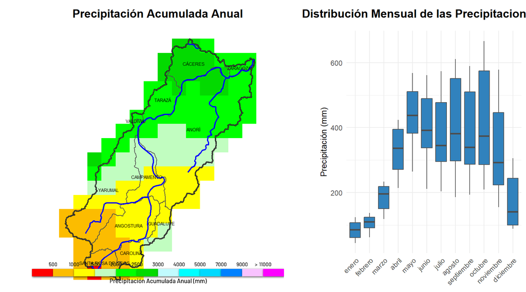

Los productores deben estar atentos a los riesgos de inundaciones y deslizamientos en los meses de alta precipitación, especialmente de agosto a octubre. Para la planificación agrícola, es recomendable programar siembras antes de las lluvias fuertes y considerar cultivos resistentes al exceso de agua.

La cuenca Nechi Antioquia presenta un régimen pluviométrico monomodal, con una única temporada seca al año. Esta temporada seca ocurre generalmente de diciembre a febrero, donde se registran precipitaciones relativamente limitadas, siendo enero el mes más seco con una mediana de 86.3 mm. La identificación de estos patrones es crucial para optimizar las prácticas agrícolas y asegurar una adecuada gestión del agua.

### Predicción Climática (6 meses)

#### Análisis del comportamiento histórico de la precipitación en la cuenca Cuenca Nechi Antioquia

El régimen de lluvias en la cuenca Cuenca Nechi Antioquia muestra variaciones significativas a lo largo de los próximos seis meses. Históricamente, se observa que en agosto la mediana de precipitación es de **409.6 mm**, lo que indica un periodo de lluvias intensas y un riesgo elevado de crecientes y desbordamientos en los ríos. Este comportamiento se mantiene en septiembre, con una mediana de **362.8 mm**, lo que refuerza la tendencia hacia condiciones de lluvias intensas.

Finalmente, en enero, la mediana se reduce considerablemente a **83.9 mm**, marcando el inicio de un periodo seco, que se considera bajo, con implicaciones negativas para el nivel del río y la disponibilidad de agua para los cultivos, especialmente en el caso del arroz, que requiere un suministro constante de agua.

En resumen, el análisis de las precipitaciones en la cuenca revela un ciclo de lluvias intensas seguido de un periodo seco, lo que deberá ser considerado en la planificación de cultivos y en la gestión de recursos hídricos.

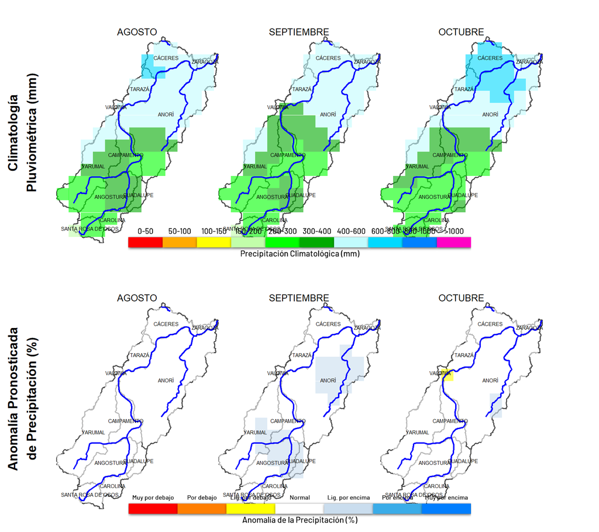

#### Análisis de Cambios en la Precipitación Acumulada para la Cuenca Nechi, Antioquia

Las proyecciones de cambio en la precipitación acumulada para la Cuenca Nechi, Antioquia, muestran una tendencia de incremento moderado a lo largo de los meses pronosticados. En agosto de 2025, se espera un aumento del 3.4%, que se incrementa a un 7.1% en septiembre. Esta tendencia ascendente sugiere un inicio de temporada de lluvias más activo.

Para octubre de 2025, la proyección indica un leve incremento del 2.1%, lo que podría ser un indicativo de una pausa en el aumento. Sin embargo, se espera que esta pausa sea temporal, ya que en noviembre se prevé un notable incremento del 6.6%. Este patrón de aumento se mantiene, con un 5.5% en diciembre y un significativo 9.7% en enero de 2026.

En resumen, la cuenca Nechi presenta pronósticos que sugieren un aumento constante en la precipitación acumulada, con picos significativos en los últimos meses del año. Esto puede implicar un potencial impacto positivo en los cultivos, incluyendo el arroz, aunque también es necesario considerar los riesgos asociados a un aumento en la intensidad de las lluvias, como inundaciones o erosión del suelo.

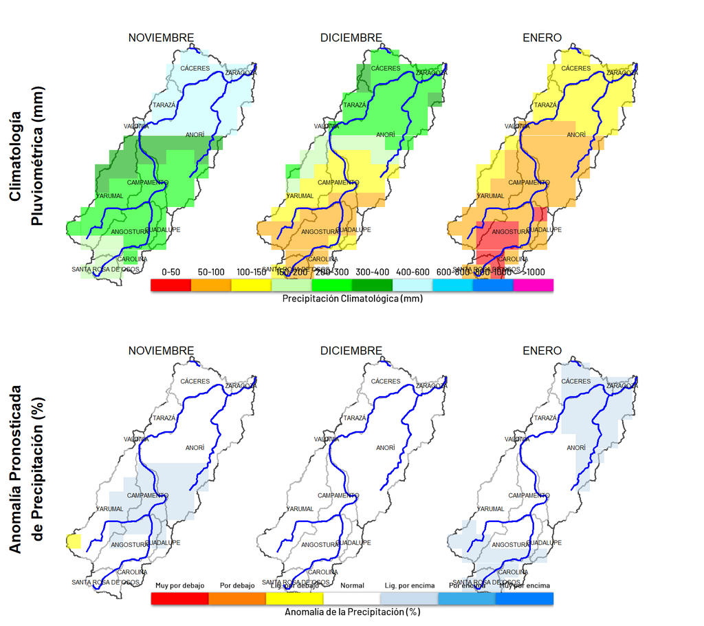

#### Pronóstico de Precipitación para la Cuenca Nechi, Antioquia

Se prevé que la cuenca Nechi en Antioquia experimente una evolución significativa en los volúmenes de precipitación durante los próximos meses.

- **Agosto 2025**: Los modelos indican que se pronostican 432.0 mm de lluvia, con una probabilidad de acierto de aproximadamente 54%. Este volumen elevado puede generar un riesgo de inundaciones, dada su superación del umbral de 300 mm.
- **Septiembre 2025**: Se estima un total de 385.8 mm, con un 59% de probabilidad de acierto. Al igual que en agosto, los niveles pronosticados sugieren un potencial riesgo de inundaciones, por lo que es crucial monitorear los sistemas de drenaje en la región.
- **Octubre 2025**: La precipitación pronosticada se sitúa en 395.6 mm, con una probabilidad de 56%. La inestabilidad en esta cifra también podría contribuir a inundaciones, dependiendo de la saturación del suelo y la capacidad de absorción en los meses anteriores.
- **Noviembre 2025**: Se anticipan 351.1 mm de lluvia, con un 58% de probabilidad de acierto. Este volumen nuevamente plantea riesgos de inundaciones, manteniendo la alerta en la cuenca.
- **Diciembre 2025**: Para este mes, se espera una disminución notable a 158.7 mm, con una probabilidad de 62%. Aunque no se superan los 300 mm, la reducción puede generar situaciones de estrés hídrico, especialmente para cultivos dependientes de humedad constante.
- **Enero 2026**: Con 88.2 mm pronosticados y una probabilidad de 62%, se anticipa un mes seco que podría acentuar el estrés hídrico en la región, afectando la agricultura y la disponibilidad de agua.

### Pronóstico de tiempo (7 dias)

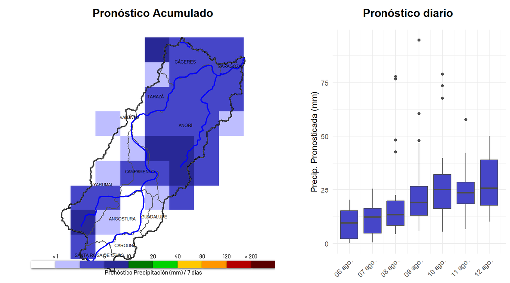

Para la Cuenca Nechí en Antioquia, se anticipa una semana con precipitaciones intensas, con volúmenes especialmente elevados hacia el final de la semana. Los días 10 y 12 de agosto se destacan con expectativas de precipitación significativa, donde se prevén volúmenes elevados. La mediana de precipitación esperada para estos días sugiere que podrían ocurrir acumulaciones que superen los 25 mm, lo cual podría tener un impacto notable en la calidad del suelo y en el riego de cultivos.

En los primeros días, del 6 al 9 de agosto, también se pronostican volúmenes moderados a elevados, con acumulaciones que oscilan entre 10 mm y 19 mm, lo que indica un inicio de semana con condiciones bastante húmedas. La probabilidad de tiempo húmedo es notablemente alta, con un 89.3% el 6 de agosto y alcanzando casi el 100% en los días subsiguientes. Esto sugiere que es muy probable que se experimente lluvia en la cuenca durante toda la semana.

En resumen, se prevé una semana marcada por intensas precipitaciones, lo que podría beneficiar a los cultivos en la región pero también podría generar riesgos de erosión y escorrentía. Se recomienda a los agricultores estar atentos a las condiciones climáticas para minimizar posibles impactos adversos en sus actividades. (IDEAM - WRF COLOMBIA)

### Seguimiento Meteorológico

**Nota:** para esta cuenca no existe información meteorológica.

# Referencias

- IDEAM. (s. f.). *Boletín Semanal para el Sector Agrícola (BSA)*. Recuperado de https://www.ideam.gov.co/sala-de-prensa/boletines/Bolet%C3%ADn-Semanal-para-el-Sector-Agr%C3%ADcola-(BSA)
- IDEAM. (s. f.). *Boletín de seguimiento al ciclo ENOS*. Recuperado de https://www.ideam.gov.co/sala-de-prensa/boletines/Bolet%C3%ADn-de-seguimiento-al-ciclo-ENOS
- Climate Prediction Center, NOAA. (s. f.). *ENSO: El Niño–Oscilación del Sur*. Recuperado de https://www.cpc.ncep.noaa.gov/products/ precip/CWlink/MJO/enso.shtml
- Climate Prediction Center, NOAA. (s. f.). *Madden–Julian Oscillation (MJO)*. Recuperado de https://www.cpc.ncep.noaa.gov/products/ precip/CWlink/MJO/mjo.shtml
- Ruiz, J. F., & Melo, J. Y. (2025). *Modelación Numérica de Tiempo y Clima IDEAM*. Bogotá D.C., Colombia. Recuperado de http://bart.ideam.gov.co/wrfideam/

Servicio Climático FEDEARROZ- FNA. Visita https://clima.fedearroz.com.co/